# Summarizer README

# 1 Summarise variables/factors by a categorical variable

`summary.factorlist()` is a simple wrapper used to summarise any number of variables by a single categorical variable. This is usually “Table 1” of a study report.

```r
library(summarizer)
library(dplyr)
library(stringr)

# Load example dataset, modified version of survival::colon
data(colon_s)

# Table 1 - Patient demographics ----
explanatory = c("age", "age.factor", "sex.factor", "obstruct.factor")
dependent = "perfor.factor"
colon_s %>%
  summary.factorlist(dependent, explanatory, p=T)
```

|  | label | levels | No | Yes | pvalue |
| --- | --- | --- | --- | --- | --- |
| 1 | Age (years) | Mean (SD) | 59.8 (11.9) | 58.4 (13.3) | 0.578 |
| 2 | Age | <40 years | 68 (97.1) | 2 (2.9) | 1.000 |
| 3 |  | 40-59 years | 334 (97.1) | 10 (2.9) |  |
| 4 |  | 60+ years | 500 (97.1) | 15 (2.9) |  |
| 7 | Sex | Female | 432 (97.1) | 13 (2.9) | 0.979 |
| 8 |  | Male | 470 (97.1) | 14 (2.9) |  |
| 5 | Obstruction | No | 715 (97.7) | 17 (2.3) | 0.018 |
| 6 |  | Yes | 166 (94.3) | 10 (5.7) |  |

`summary.factorlist()` is also commonly used to summarise any number of variables by an *outcome variable* (say dead yes/no).

```r
# Table 2 - 5 yr mortality ----
explanatory = c("age.factor", "sex.factor", "obstruct.factor", "perfor.factor")
dependent = 'mort_5yr'
colon_s %>%
  summary.factorlist(dependent, explanatory)
```

|  | label | levels | Alive | Died |
| --- | --- | --- | --- | --- |
| 1 | Age | <40 years | 31 (46.3) | 36 (53.7) |
| 2 |  | 40-59 years | 208 (61.4) | 131 (38.6) |
| 3 |  | 60+ years | 272 (53.4) | 237 (46.6) |
| 8 | Sex | Female | 243 (55.6) | 194 (44.4) |
| 9 |  | Male | 268 (56.1) | 210 (43.9) |
| 4 | Obstruction | No | 408 (56.7) | 312 (43.3) |
| 5 |  | Yes | 89 (51.1) | 85 (48.9) |
| 6 | Perforation | No | 497 (56.0) | 391 (44.0) |
| 7 |  | Yes | 14 (51.9) | 13 (48.1) |

# 2 Summarise regression model results in final table format

The second main feature is the ability to create final tables for logistic `glm()`, hierarchical logistic `lme4::glmer()` and Cox proprotional hazard `survival::coxph()` regression models.

The `summarizer()` “all-in-one” function takes a single dependent variable with a vector of explanatory variable names (continuous or categorical variables) to produce a final table for publication including summary statistics, univariable and multivariable regression analyses. The first columns are those produced by `summary.factorist()`.

## 2.1 glm

`glm(depdendent ~ explanatory, family="binomial")`

```r
explanatory = c("age.factor", "sex.factor", "obstruct.factor", "perfor.factor")
dependent = 'mort_5yr'
colon_s %>%
  summarizer(dependent, explanatory)
```

|  | label | levels | Alive | Died | OR (univariable) | OR (multivariable) |
| --- | --- | --- | --- | --- | --- | --- |
| 1 | Age | <40 years | 31 (6.1) | 36 (8.9) | - | - |
| 2 |  | 40-59 years | 208 (40.7) | 131 (32.4) | 0.54 (0.32-0.92, p=0.023) | 0.57 (0.34-0.98, p=0.041) |
| 3 |  | 60+ years | 272 (53.2) | 237 (58.7) | 0.75 (0.45-1.25, p=0.270) | 0.81 (0.48-1.36, p=0.426) |
| 8 | Sex | Female | 243 (47.6) | 194 (48.0) | - | - |
| 9 |  | Male | 268 (52.4) | 210 (52.0) | 0.98 (0.76-1.27, p=0.889) | 0.98 (0.75-1.28, p=0.902) |
| 4 | Obstruction | No | 408 (82.1) | 312 (78.6) | - | - |
| 5 |  | Yes | 89 (17.9) | 85 (21.4) | 1.25 (0.90-1.74, p=0.189) | 1.25 (0.90-1.76, p=0.186) |
| 6 | Perforation | No | 497 (97.3) | 391 (96.8) | - | - |
| 7 |  | Yes | 14 (2.7) | 13 (3.2) | 1.18 (0.54-2.55, p=0.672) | 1.12 (0.51-2.44, p=0.770) |

Where a multivariable model contains a subset of the variables specified in the full univariable set, this can be specified.

```r
explanatory = c("age.factor", "sex.factor", "obstruct.factor", "perfor.factor")
explanatory.multi = c("age.factor", "obstruct.factor")
dependent = 'mort_5yr'
colon_s %>%
  summarizer(dependent, explanatory, explanatory.multi)
```

|  | label | levels | Alive | Died | OR (univariable) | OR (multivariable) |
| --- | --- | --- | --- | --- | --- | --- |
| 1 | Age | <40 years | 31 (6.1) | 36 (8.9) | - | - |
| 2 |  | 40-59 years | 208 (40.7) | 131 (32.4) | 0.54 (0.32-0.92, p=0.023) | 0.57 (0.34-0.98, p=0.041) |
| 3 |  | 60+ years | 272 (53.2) | 237 (58.7) | 0.75 (0.45-1.25, p=0.270) | 0.81 (0.48-1.36, p=0.424) |
| 8 | Sex | Female | 243 (47.6) | 194 (48.0) | - | - |
| 9 |  | Male | 268 (52.4) | 210 (52.0) | 0.98 (0.76-1.27, p=0.889) | - |
| 4 | Obstruction | No | 408 (82.1) | 312 (78.6) | - | - |
| 5 |  | Yes | 89 (17.9) | 85 (21.4) | 1.25 (0.90-1.74, p=0.189) | 1.26 (0.90-1.76, p=0.176) |
| 6 | Perforation | No | 497 (97.3) | 391 (96.8) | - | - |
| 7 |  | Yes | 14 (2.7) | 13 (3.2) | 1.18 (0.54-2.55, p=0.672) | - |

## 2.3 Random effects.

`lme4::glmer(dependent ~ explanatory + (1 | random_effect), family="binomial")`

```r
explanatory = c("age.factor", "sex.factor", "obstruct.factor", "perfor.factor")
explanatory.multi = c("age.factor", "obstruct.factor")
random.effect = "hospital"
dependent = 'mort_5yr'
colon_s %>%
  summarizer(dependent, explanatory, explanatory.multi, random.effect)
```

|  | label | levels | Alive | Died | OR (univariable) | OR (multilevel) |
| --- | --- | --- | --- | --- | --- | --- |
| 1 | Age | <40 years | 31 (6.1) | 36 (8.9) | - | - |
| 2 |  | 40-59 years | 208 (40.7) | 131 (32.4) | 0.54 (0.32-0.92, p=0.023) | 0.73 (0.38-1.40, p=0.342) |
| 3 |  | 60+ years | 272 (53.2) | 237 (58.7) | 0.75 (0.45-1.25, p=0.270) | 1.01 (0.53-1.90, p=0.984) |
| 8 | Sex | Female | 243 (47.6) | 194 (48.0) | - | - |
| 9 |  | Male | 268 (52.4) | 210 (52.0) | 0.98 (0.76-1.27, p=0.889) | - |
| 4 | Obstruction | No | 408 (82.1) | 312 (78.6) | - | - |
| 5 |  | Yes | 89 (17.9) | 85 (21.4) | 1.25 (0.90-1.74, p=0.189) | 1.24 (0.83-1.85, p=0.292) |
| 6 | Perforation | No | 497 (97.3) | 391 (96.8) | - | - |
| 7 |  | Yes | 14 (2.7) | 13 (3.2) | 1.18 (0.54-2.55, p=0.672) | - |

## 2.4 with metrics

`metrics=TRUE` provides common model metrics. *note - defaults to data.frame print out - kable doesn’t handle list automatically*

```r
colon_s %>%
  summarizer(dependent, explanatory, explanatory.multi,  metrics=TRUE)
```

```
## [[1]]
##         label      levels      Alive       Died          OR (univariable)
## 1         Age   <40 years   31 (6.1)   36 (8.9)                         -
## 2             40-59 years 208 (40.7) 131 (32.4) 0.54 (0.32-0.92, p=0.023)
## 3               60+ years 272 (53.2) 237 (58.7) 0.75 (0.45-1.25, p=0.270)
## 8         Sex      Female 243 (47.6) 194 (48.0)                         -
## 9                    Male 268 (52.4) 210 (52.0) 0.98 (0.76-1.27, p=0.889)
## 4 Obstruction          No 408 (82.1) 312 (78.6)                         -
## 5                     Yes  89 (17.9)  85 (21.4) 1.25 (0.90-1.74, p=0.189)
## 6 Perforation          No 497 (97.3) 391 (96.8)                         -
## 7                     Yes   14 (2.7)   13 (3.2) 1.18 (0.54-2.55, p=0.672)
##          OR (multivariable)
## 1                         -
## 2 0.57 (0.34-0.98, p=0.041)
## 3 0.81 (0.48-1.36, p=0.424)
## 8                         -
## 9                         -
## 4                         -
## 5 1.26 (0.90-1.76, p=0.176)
## 6                         -
## 7                         -
##
## [[2]]
## [1] "Number in dataframe = 929, Number in model = 894, Missing = 35, AIC = 1226.8, C-statistic = 0.555"
```

## 2.5 Cox proportional hazards

`survival::coxph(dependent ~ explanatory)`

```r
explanatory = c("age.factor", "sex.factor", "obstruct.factor", "perfor.factor")
dependent = "Surv(time, status)"

colon_s %>%
    summarizer(dependent, explanatory)
```

|  | label | levels | HR (univariable) | HR (multivariable) |
| --- | --- | --- | --- | --- |
| 1 | Age | <40 years | - | - |
| 2 |  | 40-59 years | 0.76 (0.53-1.09, p=0.132) | 0.79 (0.55-1.13, p=0.196) |
| 3 |  | 60+ years | 0.93 (0.66-1.31, p=0.668) | 0.98 (0.69-1.40, p=0.926) |
| 8 | Sex | Female | - | - |
| 9 |  | Male | 1.01 (0.84-1.22, p=0.888) | 1.02 (0.85-1.23, p=0.812) |
| 4 | Obstruction | No | - | - |
| 5 |  | Yes | 1.29 (1.03-1.62, p=0.028) | 1.30 (1.03-1.64, p=0.026) |
| 6 | Perforation | No | - | - |
| 7 |  | Yes | 1.17 (0.70-1.95, p=0.556) | 1.08 (0.64-1.81, p=0.785) |

# 3 Subsets

Rather than going all-in-one, any number of subset models can be manually added on to a `summary.factorlist()` table using `summarizer.merge()`. This is particularly useful when models take a long-time to run or are complicated.

## 3.1 glm

Note requirement for `glm.id=TRUE`. `fit2df` is a subfunction extracting most common models to a dataframe.

```r
explanatory = c("age.factor", "sex.factor", "obstruct.factor", "perfor.factor")
explanatory.multi = c("age.factor", "obstruct.factor")
random.effect = "hospital"
dependent = 'mort_5yr'

# Separate tables
colon_s %>%
  summary.factorlist(dependent, explanatory, glm.id=TRUE) -> example.summary

colon_s %>%
  glmuni(dependent, explanatory) %>%
  fit2df(estimate.suffix=" (univariable)") -> example.univariable

colon_s %>%
  glmmulti(dependent, explanatory) %>%
  fit2df(estimate.suffix=" (multivariable)") -> example.multivariable


colon_s %>%
  glmmixed(dependent, explanatory, random.effect) %>%
  fit2df(estimate.suffix=" (multilevel") -> example.multilevel

# Pipe together
example.summary %>%
  summarizer.merge(example.univariable) %>%
  summarizer.merge(example.multivariable) %>%
  summarizer.merge(example.multilevel) %>%
  select(-c(glm.id, index)) -> example.final
example.final
```

|  | label | levels | Alive | Died | OR (univariable) | OR (multivariable) | OR (multilevel |
| --- | --- | --- | --- | --- | --- | --- | --- |
| 1 | Age | <40 years | 31 (46.3) | 36 (53.7) | - | - | - |
| 2 |  | 40-59 years | 208 (61.4) | 131 (38.6) | 0.54 (0.32-0.92, p=0.023) | 0.57 (0.34-0.98, p=0.041) | 0.75 (0.39-1.44, p=0.382) |
| 3 |  | 60+ years | 272 (53.4) | 237 (46.6) | 0.75 (0.45-1.25, p=0.270) | 0.81 (0.48-1.36, p=0.426) | 1.03 (0.55-1.96, p=0.916) |
| 8 | Sex | Female | 243 (55.6) | 194 (44.4) | - | - | - |
| 9 |  | Male | 268 (56.1) | 210 (43.9) | 0.98 (0.76-1.27, p=0.889) | 0.98 (0.75-1.28, p=0.902) | 0.80 (0.58-1.11, p=0.180) |
| 4 | Obstruction | No | 408 (56.7) | 312 (43.3) | - | - | - |
| 5 |  | Yes | 89 (51.1) | 85 (48.9) | 1.25 (0.90-1.74, p=0.189) | 1.25 (0.90-1.76, p=0.186) | 1.23 (0.82-1.83, p=0.320) |
| 6 | Perforation | No | 497 (56.0) | 391 (44.0) | - | - | - |
| 7 |  | Yes | 14 (51.9) | 13 (48.1) | 1.18 (0.54-2.55, p=0.672) | 1.12 (0.51-2.44, p=0.770) | 1.03 (0.43-2.51, p=0.940) |

## 3.2 Cox Proportional Hazards example with separate tables merged together.

```r
explanatory = c("age.factor", "sex.factor", "obstruct.factor", "perfor.factor")
explanatory.multi = c("age.factor", "obstruct.factor")
dependent = "Surv(time, status)"

# Separate tables
colon_s %>%
    summary.factorlist(dependent, explanatory, glm.id=TRUE) -> example2.summary
colon_s %>%
    coxphuni(dependent, explanatory) %>%
    fit2df(estimate.suffix=" (univariable)") -> example2.univariable

colon_s %>%
  coxphmulti(dependent, explanatory.multi) %>%
  fit2df(estimate.suffix=" (multivariable)") -> example2.multivariable

# Pipe together
example2.summary %>%
    summarizer.merge(example2.univariable) %>%
    summarizer.merge(example2.multivariable) %>%
    select(-c(glm.id, index)) -> example2.final
example2.final
```

|  | label | levels | all | HR (univariable) | HR (multivariable) |
| --- | --- | --- | --- | --- | --- |
| 1 | Age | <40 years | 70 (100.0) | - | - |
| 2 |  | 40-59 years | 344 (100.0) | 0.76 (0.53-1.09, p=0.132) | 0.79 (0.55-1.14, p=0.203) |
| 3 |  | 60+ years | 515 (100.0) | 0.93 (0.66-1.31, p=0.668) | 0.99 (0.70-1.40, p=0.943) |
| 8 | Sex | Female | 445 (100.0) | - | - |
| 9 |  | Male | 484 (100.0) | 1.01 (0.84-1.22, p=0.888) | - |
| 4 | Obstruction | No | 732 (100.0) | - | - |
| 5 |  | Yes | 176 (100.0) | 1.29 (1.03-1.62, p=0.028) | 1.31 (1.04-1.64, p=0.022) |
| 6 | Perforation | No | 902 (100.0) | - | - |
| 7 |  | Yes | 27 (100.0) | 1.17 (0.70-1.95, p=0.556) | - |

# 4 Summarise regression model results in plot

Models can be summarized with odds ratio/hazard ratio plots using `or.plot` or `hr.plot` (hr.plot not fully tested).

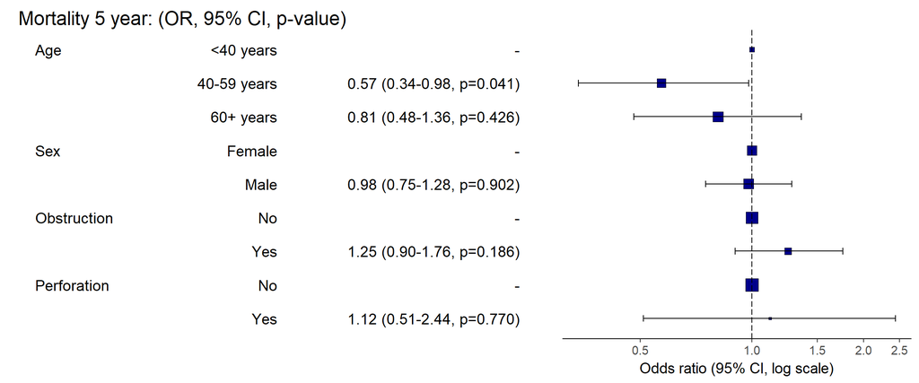

```r
# OR plot
explanatory = c("age.factor", "sex.factor", "obstruct.factor", "perfor.factor")
dependent = 'mort_5yr'
colon_s %>%
  or.plot(dependent, explanatory)
```

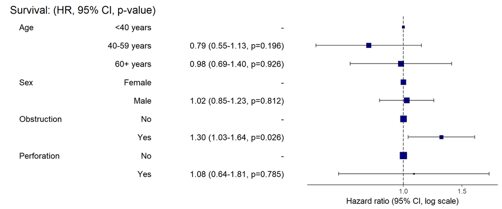

```r
# Previously fitted models (`glmmulti`) can be provided directly to `glmfit`

# HR plot (not fully tested)
explanatory = c("age.factor", "sex.factor", "obstruct.factor", "perfor.factor")
dependent = "Surv(time, status)"
colon_s %>%
  hr.plot(dependent, explanatory, dependent_label = "Survival")
```

```r
# Previously fitted models (`coxphmulti`) can be provided directly using `coxfit`
```

Our own particular `Rstan` models are supported and will be documented in the future. Broadly, if you are running (hierarchical) logistic regression models in [Stan](http://mc-stan.org/users/interfaces/rstan) with coefficients specified as a vector labelled `beta`, then `fit2df()` will work directly on the `stanfit` object in a similar manner to if it was a `glm` or `glmerMod` object.

# 5 Notes

Use `Hmisc::label()` to assign labels to variables for tables and plots.

```r
label(colon_s$age.factor) = "Age (years)"
```

Export dataframe tables directly or to [R Markdown](http://rmarkdown.rstudio.com) using [`knitr::kable()`](https://yihui.name/knitr/).

Note wrapper `summary.missing()` can be useful. Wraps `mice::md.pattern`.

```r
colon_s %>%
  summary.missing(dependent, explanatory)
```

```
##     sex.factor perfor.factor age.factor obstruct.factor
## 908          1             1          1               1  0
##  21          1             1          1               0  1
##              0             0          0              21 21
```